# Analysis and Control Structures

## Basic Anova: Continuous vs. Categorical

#### Was there a statistically significant difference in the number of adults among wetlands?

```r
ANOmodel <- aov(count.total.adults~factor(wetland),data=dryadData) #factor(wetland) groups the numbered wetlands into categorical

summary(ANOmodel)
```

```
##                  Df Sum Sq Mean Sq F value   Pr(>F)
## factor(wetland)  10 224844   22484   5.696 6.09e-07 ***
## Residuals       119 469747    3947
## ---
## Signif. codes:  0 '***' 0.001 '**' 0.01 '*' 0.05 '.' 0.1 ' ' 1
## 2 observations deleted due to missingness
```

```r
dryadData %>%
  group_by(wetland) %>%
  summarize(avgHydro = mean(count.total.adults, na.rm=T), n=n())
```

```
## # A tibble: 11 × 3
##    wetland avgHydro     n
##      <int>    <dbl> <int>
##  1       7    70.5     12
##  2      19    56.4     12
##  3      20   113.      12
##  4      25   133.      12
##  5      30    70.5     12
##  6      39   144.      12
##  7      55    42.3     12
##  8      59    32.5     12
##  9     124   118.      12
## 10     129     9.92    12
## 11     141    69.9     12
```

#### Boxplot

```r
dryadData$wetland <- factor(dryadData$wetland) #overwrite wetland data with factored wetland data
class(dryadData$wetland)
```

```
## [1] "factor"
```

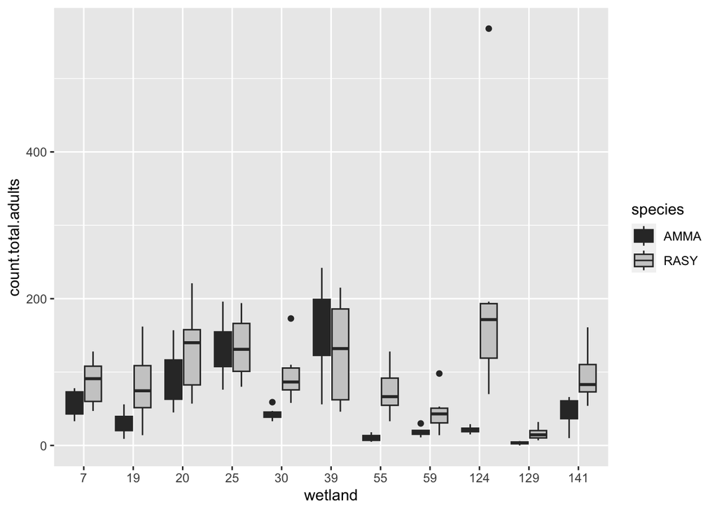

```r
ANOplot <- ggplot(data=dryadData, aes(x=wetland, y=count.total.adults, fill=species)) +
  geom_boxplot() +
  scale_fill_grey()

ANOplot
```

```r
# ggsave(file="SpeciesBoxplots.pdf", plot=ANOplot, device="pdf") save plot to pdf
```

## Logistic Regression: Categorical vs. Continuous

- gamma probabilities are best for continuous variables that are always positive and have a skewed distribution

```r
x_var <- sort(rgamma(n=200, shape=5, scale=5))
y_var <- sample(rep(c(1,0), each=100), prob=seq_len(200))
log_reg_data <- data.frame(x_var, y_var)

log_reg_model <- glm(y_var ~ x_var,      #generalized linear model
                     data=log_reg_data,
                     family=binomial(link=logit)
                  )

summary(log_reg_model)
```

```
##
## Call:
## glm(formula = y_var ~ x_var, family = binomial(link = logit),
##     data = log_reg_data)
##
## Deviance Residuals:
##     Min       1Q   Median       3Q      Max
## -1.8590  -0.8804  -0.1103   0.8879   2.2864
##
## Coefficients:
##             Estimate Std. Error z value Pr(>|z|)
## (Intercept) -3.23842    0.51968  -6.232 4.62e-10 ***
## x_var        0.13398    0.02096   6.393 1.63e-10 ***
## ---
## Signif. codes:  0 '***' 0.001 '**' 0.01 '*' 0.05 '.' 0.1 ' ' 1
##
## (Dispersion parameter for binomial family taken to be 1)
##
##     Null deviance: 277.26  on 199  degrees of freedom
## Residual deviance: 213.78  on 198  degrees of freedom
## AIC: 217.78
##
## Number of Fisher Scoring iterations: 4
```

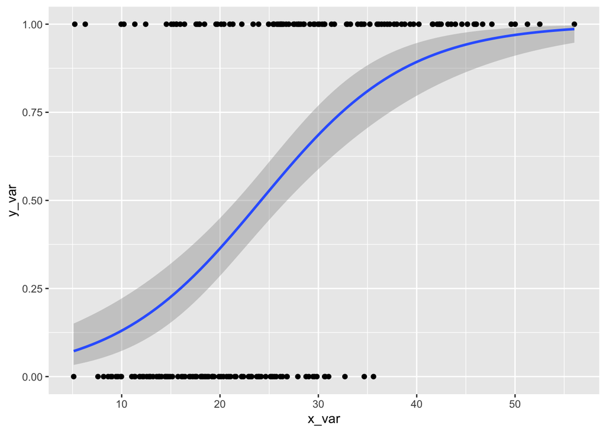

```r
log_reg_plot <- ggplot(data=log_reg_data, aes(x=x_var, y=y_var)) +
  geom_point() +
  stat_smooth(method="glm", method.args=list(family=binomial))

log_reg_plot
```

## Contingency Tables (chi-squared): Categorical vs. Categorical

#### Are there differences in counts of males and females between species?

```r
count_data <- dryadData %>%
  group_by(species) %>%
  summarize(Males = sum(No.males, na.rm=T),
            Females=sum(No.females, na.rm=T)
            ) %>%
  select(-species) %>% #get rid of names for the species
  as.matrix() #convert to matrix

count_data
```

```
##      Males Females
## [1,]  2090    1513
## [2,]  4095    2422
```

```r
row.names(count_data) =c("SS", "WF")
count_data
```

```
##    Males Females
## SS  2090    1513
## WF  4095    2422
```

```r
chisq.test(count_data)$residuals
```

```
##        Males   Females
## SS -2.387410  2.993122
## WF  1.775151 -2.225526
```

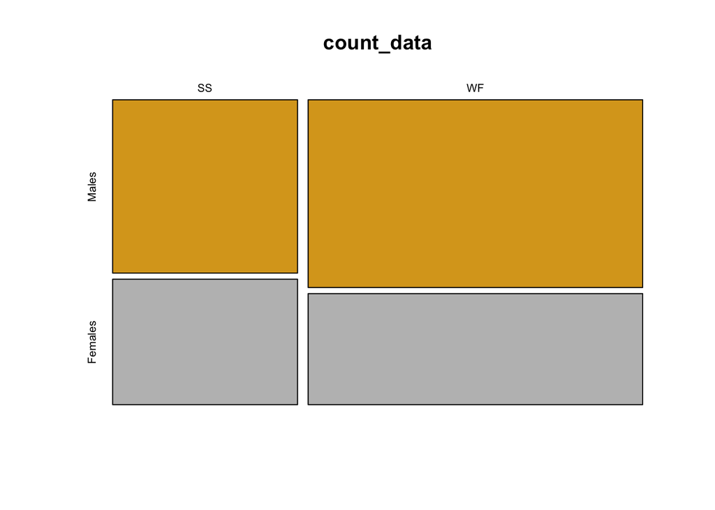

```r
# mosaic plot
mosaicplot(x=count_data, col=c("goldenrod", "gray"), shade=F)
```

```r
# bar plot
count_data_long <- count_data %>%
  as_tibble() %>%  #need to make it a tibble in order to pivot longer
  mutate(Species=c(rownames(count_data))) %>%  #use the matrix to add species names
  pivot_longer(cols=Males:Females, names_to="Sex", values_to="Count")

count_data_long
```

```
## # A tibble: 4 × 3
##   Species Sex     Count
##   <chr>   <chr>   <int>
## 1 SS      Males    2090
## 2 SS      Females  1513
## 3 WF      Males    4095
## 4 WF      Females  2422
```

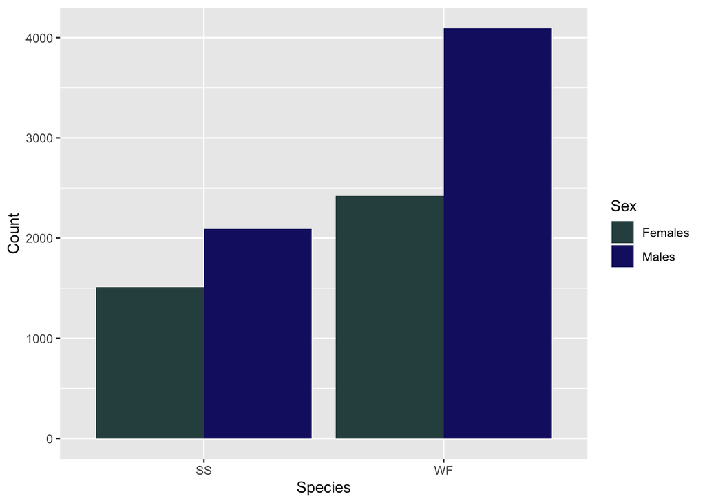

```r
plot <- ggplot(data=count_data_long, aes(x=Species, y=Count, fill=Sex)) +
  geom_bar(stat="identity", position="dodge") +
  scale_fill_manual(values=c("darkslategrey", "midnightblue"))

plot
```

```r
if(condition){expression1}

if(condition){expression1} else{expression2}

ifelse(condition, yes, no)
```

```r
z <- signif(runif(1), digits=2)

if (z>0.8){cat(z, "is a large number", "\n")} else #cat() is the concatenate function
if (z<0.2){cat(z, "is a small number", "\n")} else
  {cat(z, "is a number of typical size", "\n")
    cat("z^2 =", z^2, "\n")
    }
```

```
## 0.14 is a small number
```

#### `ifelse` to fill vectors

Insect population where the females lay on average `10.2` eggs and follows a Poisson distribution. There is a 35% chance of parasitism where no eggs are laid. Let’s make a distribution or 1000 individuals

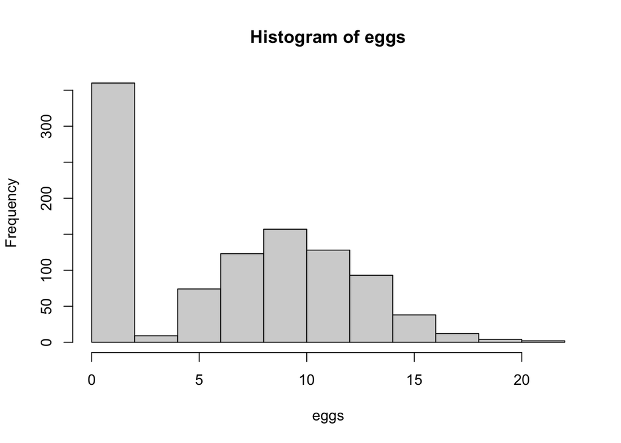

```r
tester <- runif(1000)
eggs <- ifelse(tester>0.35, rpois(n=1000, lambda=10.2), 0)
hist(eggs)
```

#### `ifelse` with a vector of p values from a simulation

We want to create a vector to highlight the significant ones for plotting

```r
p_vals <- runif(1000)
z <- ifelse(p_vals <= 0.025, "lowerTail", "nonSig")
z[p_vals>=0.975] <- "upperTail"
table(z)
```

```
## z
## lowerTail    nonSig upperTail
##        22       948        30
```

## `for` loops

- Not super popular in r
  - very slow with certain operations
  - r has vectorization
  - family of apply functions

```r
for(var in sequence){
  body of the for loop
}
```

```r
for(i in 1:5){
  cat("stuck in a loop", i, "\n")
  cat(3+2, "\n")
  cat(3+i, "\n")
}
```

```
## stuck in a loop 1
## 5
## 4
## stuck in a loop 2
## 5
## 5
## stuck in a loop 3
## 5
## 6
## stuck in a loop 4
## 5
## 7
## stuck in a loop 5
## 5
## 8
```

```r
#use a counter variable that maps to the position of each element

my_dogs <- c("chow", "akita", "malamute", "husky", "samoyed")

for(i in 1:length(my_dogs)){
  cat("i =",i,"my_dogs[i] =" ,my_dogs[i],"\n")
}
```

```
## i = 1 my_dogs[i] = chow
## i = 2 my_dogs[i] = akita
## i = 3 my_dogs[i] = malamute
## i = 4 my_dogs[i] = husky
## i = 5 my_dogs[i] = samoyed
```

#### double for loops

```r
m <- matrix(round(runif(20), digits=2), nrow=5)

for(i in 1:nrow(m)){
  m[i,] <- m[i,] + i
}

m
```

```
##      [,1] [,2] [,3] [,4]
## [1,] 1.17 1.29 1.57 1.21
## [2,] 2.16 2.16 2.91 2.28
## [3,] 3.15 3.78 3.62 3.39
## [4,] 4.63 4.26 4.84 4.40
## [5,] 5.54 5.31 5.63 5.33
```

```r
m <- matrix(round(runif(20),digits=2),nrow=5)
for (i in 1:nrow(m)) {
  for (j in 1:ncol(m)) {
    m[i,j] <- m[i,j] + i + j
  } # end of column j loop
} # end or row i loop
 print(m)
```

```
##      [,1] [,2] [,3] [,4]
## [1,] 2.21 3.37 4.67 5.39
## [2,] 3.82 4.98 5.78 6.28
## [3,] 4.61 5.93 6.57 7.12
## [4,] 5.25 6.27 7.53 8.89
## [5,] 6.35 7.44 8.21 9.88
```